# Quantification of Gene Expression with Salmon

March 2021

## Differential Gene Expression Analysis Workflow

[figure not shown]

## A Simple Counting Approach

We now have the locations of our reads on the genome.

We also know the locations of exons of genes on the genome.

So the simplest approach is to count how many reads overlap each gene.

[figure not shown]

## A Simple Counting Approach

We now have the locations of our reads on the genome.

We also know the locations of exons of genes on the genome.

So the simplest approach is to count how many reads overlap each gene.

[figure not shown]

e.g. featureCounts or HTSeq

## Problems with the Simple Counting Approach

- Genes have multiple transcripts, alternative splicing introduces ambiguity
- Traditional alignment is (relatively) slow and computationally intensive
- Read sampling is not uniform, there are biases

## Problems with the Simple Counting Approach

- Genes have multiple transcripts, alternative splicing introduces ambiguity
- Traditional alignment is (relatively) slow and computationally intensive
- Read sampling is not uniform, there are biases

More sophisticates approaches:

- CuffLinks - Trapnell *et al.* (2010) Nature Biotechnology doi:10.1038/nbt.1621
- RSEM - Li and Dewey (2011) BMC Bioinformatics doi:10.1186/1471-2105-12-323
- Sailfish - Patro *et al.* (2014) Nature Biotechnology doi:10.1038/nbt.2862
- Kallisto - Bary *et al.* (2016) Nature Biotechnology doi:10.1038/nbt.3519
- **Salmon** - Patro *et al.* (2017) Nature Methods doi:10.1038/nmeth.4197

## Problems with the Simple Counting Approach

- Genes have multiple transcripts, alternative splicing introduces ambiguity

Count against the transcriptome instead.

Summarise to gene level for differential gene expression analysis.

## Quasi-mapping/Pseudo-alignment

- Traditional alignment is (relatively) slow and computationally intensive

Switch to *quasi-mapping* or *pseudo-alignment* to transcriptome

[figure not shown]

## Quasi-mapping/Pseudo-alignment

- Traditional alignment is (relatively) slow and computationally intensive

Switch to *quasi-mapping* or *pseudo-alignment*

[figure not shown]

## Quasi-mapping/Pseudo-alignment

- Traditional alignment is (relatively) slow and computationally intensive

Switch to *quasi-mapping* or *pseudo-alignment*

[figure not shown]

## Bias models

- Read sampling is not uniform, there are biases

Include modelling for GC bias, positional bias and sequence bias in the quantification algorithm

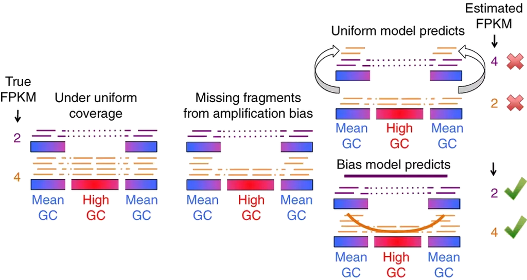

Love *et al.* (2016) Nature Biotechnology doi:10.1038/nbt.3682

## Salmon workflow

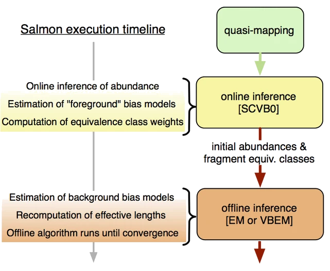

Patro *et al.* (2017) Nature Methods doi:10.1038/nmeth.4197

## Salmon workflow

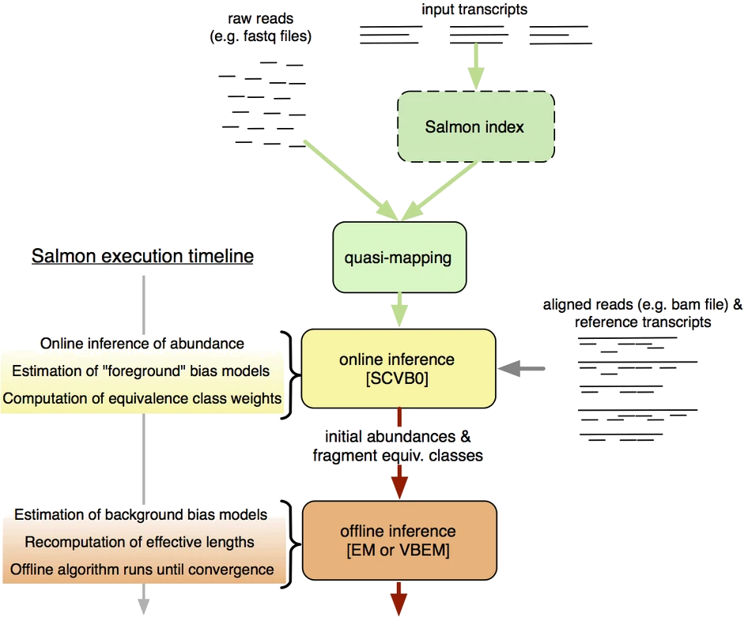

Patro *et al.* (2017) Nature Methods doi:10.1038/nmeth.4197

## Practical

1. Create and index to the transcriptome with Salmon
2. Quantify transcript expression using Salmon